# Heart Disease Risk Analysis: Cholesterol Profiles and Lifestyle Factors

Sheikh Azam Uddin

2026-06-11

# 1. Introduction

## 1.1 Problem Statement

Heart disease remains a leading cause of death globally, and its early detection is vital. Understanding how cholesterol levels — specifically total cholesterol, LDL (low-density lipoprotein), and HDL (high-density lipoprotein) — along with factors such as blood pressure, smoking, and physical activity contribute to heart disease risk is crucial for prevention strategies.

## 1.2 Research Question

To what extent do serum cholesterol profiles (total cholesterol, LDL, and HDL levels) independently predict heart disease risk, when also considering blood pressure, smoking, and physical activity?

## 1.3 Statistical Approach

Logistic regression and hypothesis testing (chi-square tests and a two-sample t-test) are used to identify and quantify associations between cholesterol profiles, lifestyle factors, and heart disease status. The logistic regression model estimates each predictor’s contribution while holding the remaining covariates constant.

## 1.4 Dataset

The dataset is sourced from Kaggle and comprises 10,000 patient records, covering cardiovascular biomarkers (blood pressure, cholesterol, triglycerides) alongside self-reported lifestyle behaviors (smoking, exercise habits) and clinical diagnoses (hypertension, HDL/LDL classifications).

**Outcome variable:** `Heart.Disease.Status` — Categorical (Yes / No)

**Predictors used in this analysis:**

| Variable | Type | Description |
| --- | --- | --- |
| `Blood.Pressure` | Numerical | Systolic blood pressure |
| `Cholesterol.Level` | Numerical | Total serum cholesterol |
| `Triglyceride.Level` | Numerical | Serum triglyceride level |
| `High.Blood.Pressure` | Categorical | Clinical hypertension (Yes / No) |
| `Exercise.Habits` | Categorical | Physical activity level (High / Medium / Low) |
| `Smoking` | Categorical | Current smoker (Yes / No) |
| `Low.HDL.Cholesterol` | Categorical | Low HDL flag (Yes / No) |
| `High.LDL.Cholesterol` | Categorical | High LDL flag (Yes / No) |

# 2. Data Loading and Preparation

## 2.1 Load Data

```r
heart_data <- read.csv("heart_disease.csv")
cat("Dataset dimensions:", nrow(heart_data), "rows x", ncol(heart_data), "columns\n")
```

```
## Dataset dimensions: 10000 rows x 21 columns
```

```r
kable(head(heart_data[, 1:8]), caption = "First 6 rows (first 8 columns shown)")
```

First 6 rows (first 8 columns shown)

| Age | Gender | Blood.Pressure | Cholesterol.Level | Exercise.Habits | Smoking | Family.Heart.Disease | Diabetes |
| --- | --- | --- | --- | --- | --- | --- | --- |
| 56 | Male | 153 | 155 | High | Yes | Yes | No |
| 69 | Female | 146 | 286 | High | No | Yes | Yes |
| 46 | Male | 126 | 216 | Low | No | No | No |
| 32 | Female | 122 | 293 | High | Yes | Yes | No |
| 60 | Male | 166 | 242 | Low | Yes | Yes | Yes |
| 25 | Male | 152 | 257 | Low | Yes | No | No |

## 2.2 Variable Selection and Outcome Encoding

```r
names(heart_data) <- make.names(names(heart_data))

num_vars <- c("Blood.Pressure", "Cholesterol.Level", "Triglyceride.Level")
cat_vars <- c("High.Blood.Pressure", "Exercise.Habits", "Smoking",
              "Low.HDL.Cholesterol", "High.LDL.Cholesterol")

heart_data <- heart_data %>%
  select(all_of(num_vars), all_of(cat_vars), Heart.Disease.Status) %>%
  filter(Heart.Disease.Status %in% c("Yes", "No")) %>%
  mutate(Heart.Disease.Status = factor(Heart.Disease.Status, levels = c("No", "Yes")))
```

## 2.3 Missing Value Imputation

```r
get_mode <- function(x) {
  ux <- na.omit(unique(x))
  ux[which.max(tabulate(match(x, ux)))]
}

heart_data[num_vars] <- lapply(heart_data[num_vars], function(x) {
  ifelse(is.na(x), median(x, na.rm = TRUE), x)
})

heart_data[cat_vars] <- lapply(heart_data[cat_vars], function(x) {
  x <- trimws(as.character(x))
  x[x == ""] <- NA
  x[is.na(x)] <- get_mode(x)
  factor(x)
})

missing_check <- data.frame(
  Variable = names(heart_data),
  Missing  = colSums(is.na(heart_data)),
  row.names = NULL
)
kable(missing_check, caption = "Missing value counts after imputation")
```

Missing value counts after imputation

| Variable | Missing |
| --- | --- |
| Blood.Pressure | 0 |
| Cholesterol.Level | 0 |
| Triglyceride.Level | 0 |
| High.Blood.Pressure | 0 |
| Exercise.Habits | 0 |
| Smoking | 0 |
| Low.HDL.Cholesterol | 0 |
| High.LDL.Cholesterol | 0 |
| Heart.Disease.Status | 0 |

Numerical variables were imputed using their **median**; categorical variables were imputed using the **mode** (most frequent category).

# 3. Descriptive Statistics

## 3.1 Numerical Variables

```r
num_summary <- data.frame(
  Variable = c("Blood Pressure", "Cholesterol Level", "Triglyceride Level"),
  N        = sapply(heart_data[, num_vars], function(x) sum(!is.na(x))),
  Mean     = sapply(heart_data[, num_vars], function(x) round(mean(x),   2)),
  Median   = sapply(heart_data[, num_vars], function(x) round(median(x), 2)),
  SD       = sapply(heart_data[, num_vars], function(x) round(sd(x),     2)),
  Min      = sapply(heart_data[, num_vars], function(x) round(min(x),    2)),
  Max      = sapply(heart_data[, num_vars], function(x) round(max(x),    2)),
  row.names = NULL
)
kable(num_summary, caption = "Summary statistics for numerical predictors")
```

Summary statistics for numerical predictors

| Variable | N | Mean | Median | SD | Min | Max |
| --- | --- | --- | --- | --- | --- | --- |
| Blood Pressure | 10000 | 149.76 | 150 | 17.56 | 120 | 180 |
| Cholesterol Level | 10000 | 225.43 | 226 | 43.51 | 150 | 300 |
| Triglyceride Level | 10000 | 250.73 | 250 | 86.95 | 100 | 400 |

## 3.2 Categorical Variables

```r
all_cat <- c(cat_vars, "Heart.Disease.Status")
for (var in all_cat) {
  freq_df <- as.data.frame(table(heart_data[[var]]))
  names(freq_df) <- c("Category", "Count")
  freq_df$Percentage <- paste0(round(prop.table(freq_df$Count) * 100, 1), "%")
  print(kable(freq_df,
              caption = paste("Distribution of:", gsub("\\.", " ", var)),
              row.names = FALSE))
}
```

```
##
##
## Table: Distribution of: High Blood Pressure
##
## |Category | Count|Percentage |
## |:--------|-----:|:----------|
## |No       |  4952|49.5%      |
## |Yes      |  5048|50.5%      |
##
##
## Table: Distribution of: Exercise Habits
##
## |Category | Count|Percentage |
## |:--------|-----:|:----------|
## |High     |  3397|34%        |
## |Low      |  3271|32.7%      |
## |Medium   |  3332|33.3%      |
##
##
## Table: Distribution of: Smoking
##
## |Category | Count|Percentage |
## |:--------|-----:|:----------|
## |No       |  4852|48.5%      |
## |Yes      |  5148|51.5%      |
##
##
## Table: Distribution of: Low HDL Cholesterol
##
## |Category | Count|Percentage |
## |:--------|-----:|:----------|
## |No       |  4975|49.8%      |
## |Yes      |  5025|50.2%      |
##
##
## Table: Distribution of: High LDL Cholesterol
##
## |Category | Count|Percentage |
## |:--------|-----:|:----------|
## |No       |  5062|50.6%      |
## |Yes      |  4938|49.4%      |
##
##
## Table: Distribution of: Heart Disease Status
##
## |Category | Count|Percentage |
## |:--------|-----:|:----------|
## |No       |  8000|80%        |
## |Yes      |  2000|20%        |
```

# 4. Data Visualization

## 4.1 Categorical Predictors vs. Heart Disease Status

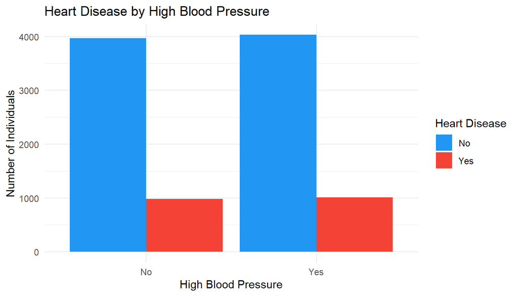

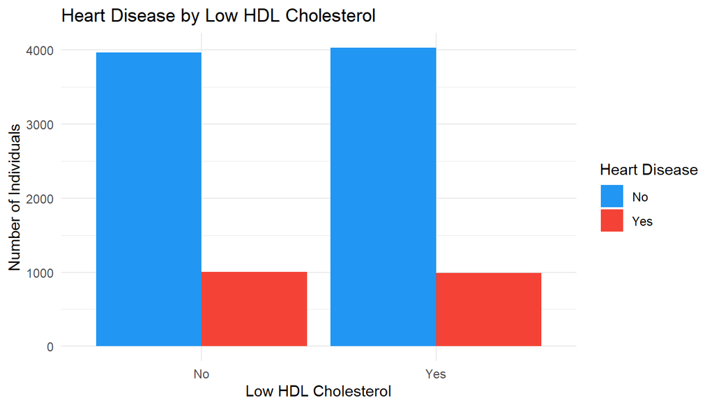

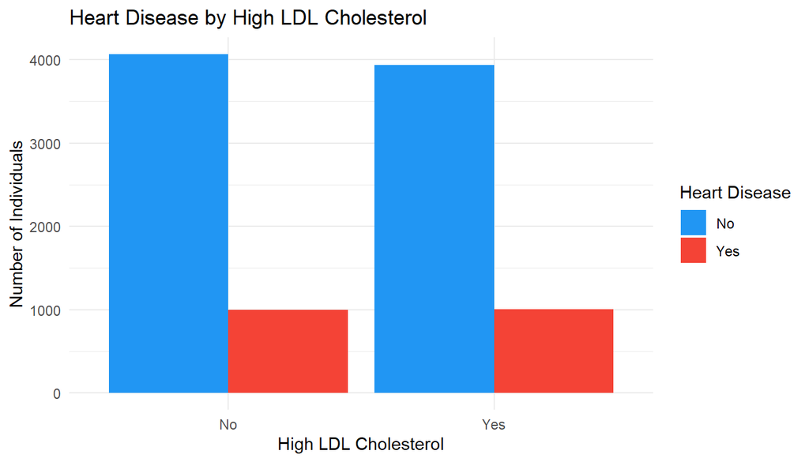

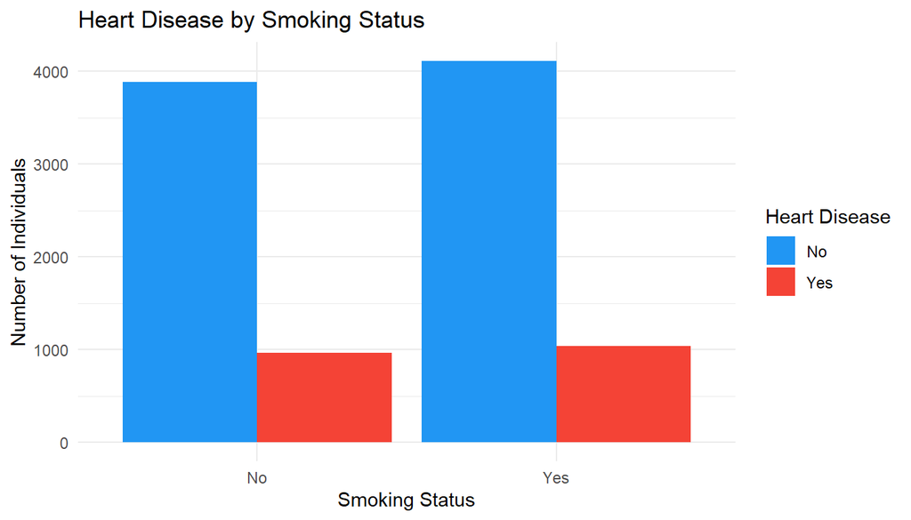

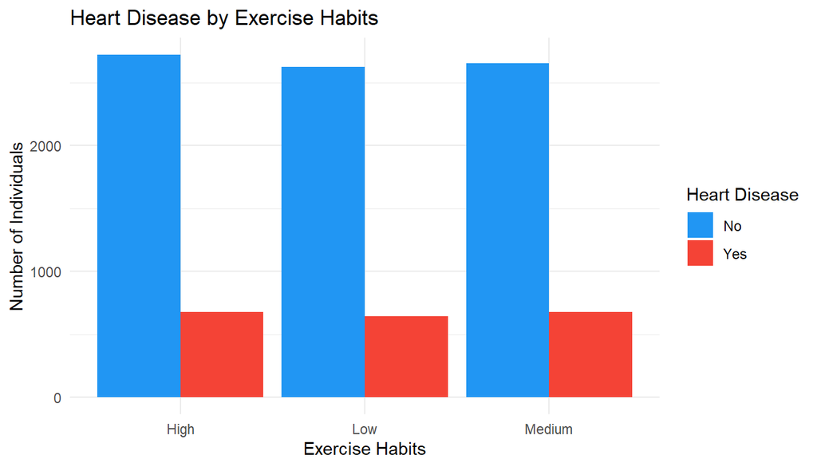

```r
plot_labels <- c(
  "High.Blood.Pressure"  = "High Blood Pressure",
  "Low.HDL.Cholesterol"  = "Low HDL Cholesterol",
  "High.LDL.Cholesterol" = "High LDL Cholesterol",
  "Smoking"              = "Smoking Status",
  "Exercise.Habits"      = "Exercise Habits"
)

for (var in names(plot_labels)) {
  p <- ggplot(heart_data, aes(x = .data[[var]], fill = Heart.Disease.Status)) +
    geom_bar(position = "dodge") +
    scale_fill_manual(values = c("No" = "#2196F3", "Yes" = "#F44336")) +
    theme_minimal() +
    labs(
      title = paste("Heart Disease by", plot_labels[[var]]),
      x     = plot_labels[[var]],
      y     = "Number of Individuals",
      fill  = "Heart Disease"
    )
  print(p)
}
```

## 4.2 Numerical Predictors vs. Heart Disease Status

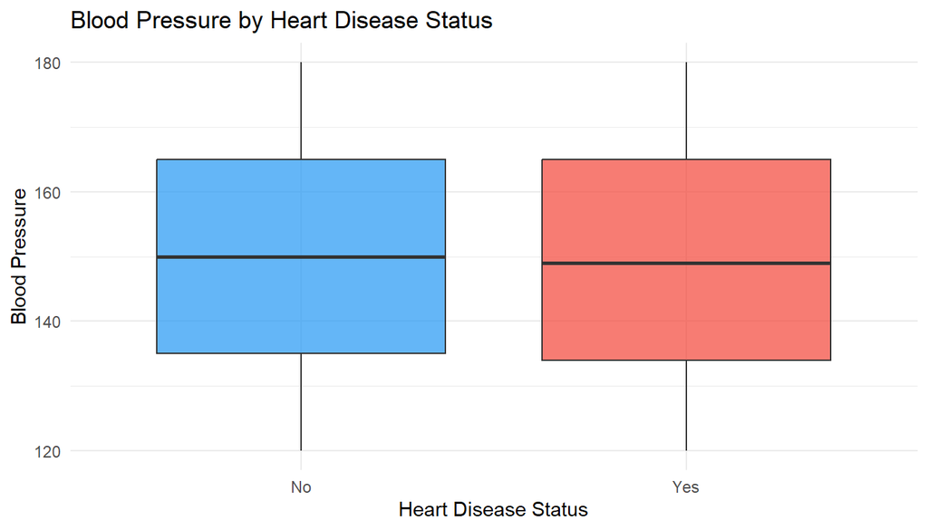

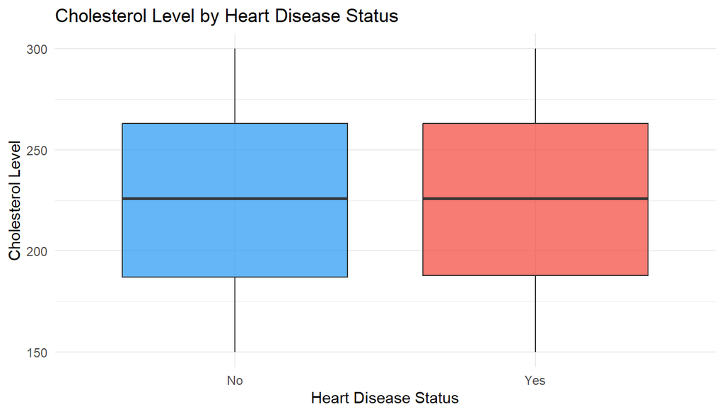

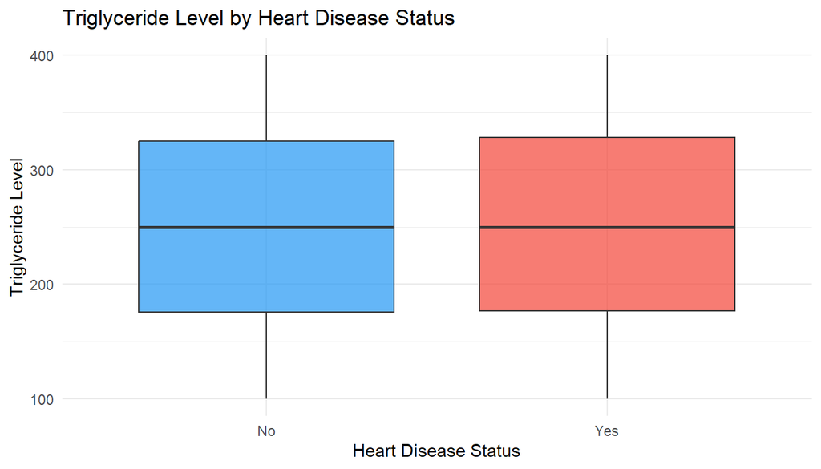

```r
box_labels <- c(
  "Blood.Pressure"     = "Blood Pressure",
  "Cholesterol.Level"  = "Cholesterol Level",
  "Triglyceride.Level" = "Triglyceride Level"
)

for (var in names(box_labels)) {
  p <- ggplot(heart_data,
              aes(x = Heart.Disease.Status, y = .data[[var]],
                  fill = Heart.Disease.Status)) +
    geom_boxplot(alpha = 0.7) +
    scale_fill_manual(values = c("No" = "#2196F3", "Yes" = "#F44336")) +
    theme_minimal() +
    theme(legend.position = "none") +
    labs(
      title = paste(box_labels[[var]], "by Heart Disease Status"),
      x     = "Heart Disease Status",
      y     = box_labels[[var]]
    )
  print(p)
}
```

## 4.3 Correlation Heatmap

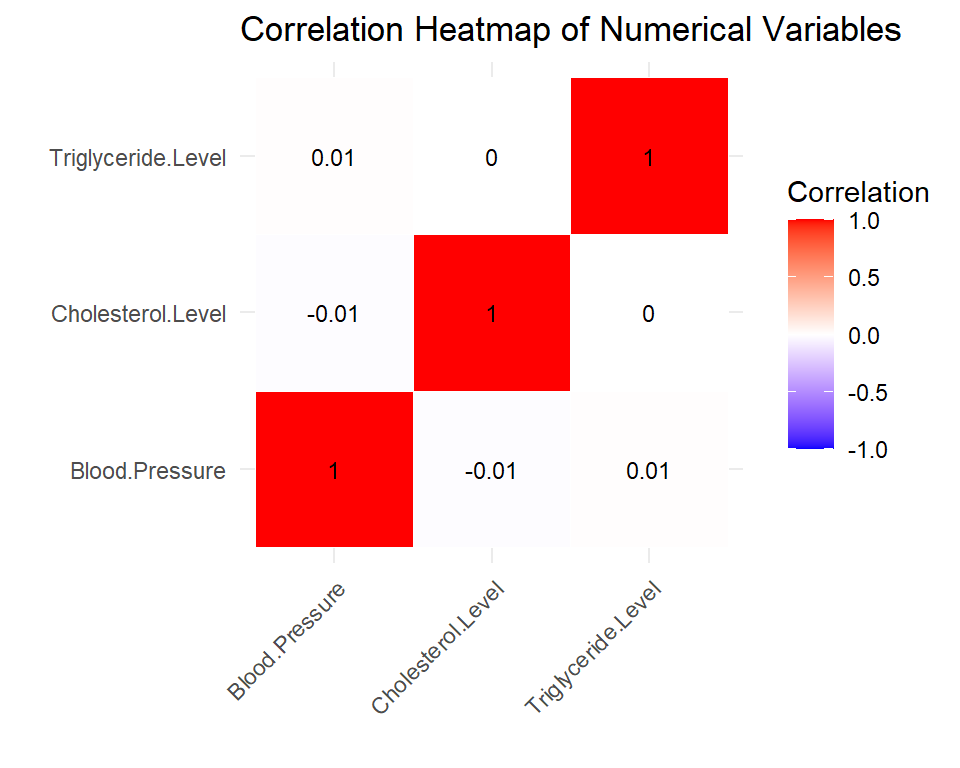

```r
numeric_cols <- names(heart_data)[sapply(heart_data, is.numeric)]
cor_matrix   <- cor(heart_data[, numeric_cols], use = "complete.obs")
cor_melted   <- melt(cor_matrix)

ggplot(cor_melted, aes(x = Var1, y = Var2, fill = value)) +
  geom_tile(color = "white") +
  geom_text(aes(label = round(value, 2)), size = 3) +
  scale_fill_gradient2(low = "blue", high = "red", mid = "white",
                       midpoint = 0, limit = c(-1, 1), name = "Correlation") +
  theme_minimal() +
  theme(axis.text.x = element_text(angle = 45, hjust = 1)) +
  labs(title = "Correlation Heatmap of Numerical Variables", x = "", y = "")
```

# 5. Statistical Analysis

## 5.1 Chi-Square Test: Low HDL Cholesterol vs. Heart Disease

```r
table_hdl <- table(heart_data$Low.HDL.Cholesterol, heart_data$Heart.Disease.Status)
kable(as.data.frame.matrix(table_hdl),
      caption = "Contingency table: Low HDL Cholesterol x Heart Disease Status")
```

Contingency table: Low HDL Cholesterol x Heart Disease Status

|  | No | Yes |
| --- | --- | --- |
| No | 3968 | 1007 |
| Yes | 4032 | 993 |

```r
hdl_test <- chisq.test(table_hdl)

kable(data.frame(
  Statistic   = round(hdl_test$statistic, 3),
  df          = hdl_test$parameter,
  `p-value`   = round(hdl_test$p.value, 4),
  check.names = FALSE
), row.names = FALSE, caption = "Chi-Square Test Result: Low HDL Cholesterol")
```

Chi-Square Test Result: Low HDL Cholesterol

| Statistic | df | p-value |
| --- | --- | --- |
| 0.331 | 1 | 0.5653 |

## 5.2 Chi-Square Test: High LDL Cholesterol vs. Heart Disease

```r
table_ldl <- table(heart_data$High.LDL.Cholesterol, heart_data$Heart.Disease.Status)
kable(as.data.frame.matrix(table_ldl),
      caption = "Contingency table: High LDL Cholesterol x Heart Disease Status")
```

Contingency table: High LDL Cholesterol x Heart Disease Status

|  | No | Yes |
| --- | --- | --- |
| No | 4066 | 996 |
| Yes | 3934 | 1004 |

```r
ldl_test <- chisq.test(table_ldl)

kable(data.frame(
  Statistic   = round(ldl_test$statistic, 3),
  df          = ldl_test$parameter,
  `p-value`   = round(ldl_test$p.value, 4),
  check.names = FALSE
), row.names = FALSE, caption = "Chi-Square Test Result: High LDL Cholesterol")
```

Chi-Square Test Result: High LDL Cholesterol

| Statistic | df | p-value |
| --- | --- | --- |
| 0.632 | 1 | 0.4266 |

## 5.3 Welch Two-Sample t-Test: Cholesterol Level by Heart Disease Status

```r
chol_ttest <- t.test(Cholesterol.Level ~ Heart.Disease.Status, data = heart_data)

kable(data.frame(
  `Mean (No)`   = round(chol_ttest$estimate[1], 2),
  `Mean (Yes)`  = round(chol_ttest$estimate[2], 2),
  `t-statistic` = round(chol_ttest$statistic, 3),
  df            = round(chol_ttest$parameter, 1),
  `p-value`     = round(chol_ttest$p.value, 4),
  check.names   = FALSE
), row.names = FALSE, caption = "Welch Two-Sample t-Test: Cholesterol Level by Heart Disease Status")
```

Welch Two-Sample t-Test: Cholesterol Level by Heart Disease Status

| Mean (No) | Mean (Yes) | t-statistic | df | p-value |
| --- | --- | --- | --- | --- |
| 225.37 | 225.66 | -0.272 | 3098.6 | 0.7857 |

## 5.4 Logistic Regression Model

```r
logit_model <- glm(
  Heart.Disease.Status ~ Cholesterol.Level + Low.HDL.Cholesterol +
    High.LDL.Cholesterol + Blood.Pressure + Smoking + Exercise.Habits,
  data   = heart_data,
  family = "binomial"
)

kable(data.frame(
  AIC                  = round(AIC(logit_model), 1),
  `Null Deviance`      = round(logit_model$null.deviance, 1),
  `Residual Deviance`  = round(logit_model$deviance, 1),
  `Degrees of Freedom` = logit_model$df.residual,
  check.names = FALSE
), row.names = FALSE, caption = "Logistic Regression Model Fit Statistics")
```

Logistic Regression Model Fit Statistics

| AIC | Null Deviance | Residual Deviance | Degrees of Freedom |
| --- | --- | --- | --- |
| 10020.5 | 10008 | 10004.5 | 9992 |

## 5.5 Odds Ratios with 95% Confidence Intervals

```r
lr_results <- tidy(logit_model, exponentiate = TRUE, conf.int = TRUE) %>%
  mutate(across(where(is.numeric), ~round(., 4))) %>%
  rename(
    Term         = term,
    `Odds Ratio` = estimate,
    SE           = std.error,
    `z-value`    = statistic,
    `p-value`    = p.value,
    `CI Lower`   = conf.low,
    `CI Upper`   = conf.high
  )

kable(lr_results, row.names = FALSE,
      caption = "Logistic Regression: Odds Ratios with 95% Confidence Intervals")
```

Logistic Regression: Odds Ratios with 95% Confidence Intervals

| Term | Odds Ratio | SE | z-value | p-value | CI Lower | CI Upper |
| --- | --- | --- | --- | --- | --- | --- |
| (Intercept) | 0.3194 | 0.2583 | -4.4190 | 0.0000 | 0.1924 | 0.5296 |
| Cholesterol.Level | 1.0001 | 0.0006 | 0.2520 | 0.8010 | 0.9990 | 1.0013 |
| Low.HDL.CholesterolYes | 0.9699 | 0.0500 | -0.6106 | 0.5414 | 0.8793 | 1.0698 |
| High.LDL.CholesterolYes | 1.0410 | 0.0500 | 0.8042 | 0.4213 | 0.9438 | 1.1483 |
| Blood.Pressure | 0.9980 | 0.0014 | -1.3887 | 0.1649 | 0.9952 | 1.0008 |
| SmokingYes | 1.0148 | 0.0501 | 0.2930 | 0.7695 | 0.9200 | 1.1194 |
| Exercise.HabitsLow | 0.9883 | 0.0615 | -0.1909 | 0.8486 | 0.8761 | 1.1149 |
| Exercise.HabitsMedium | 1.0301 | 0.0608 | 0.4874 | 0.6260 | 0.9143 | 1.1605 |

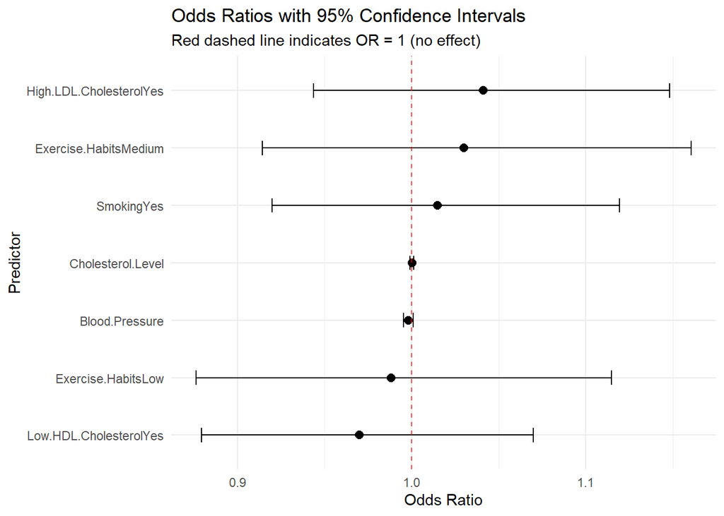

```r
odds_df <- tidy(logit_model, exponentiate = TRUE, conf.int = TRUE) %>%
  filter(term != "(Intercept)")

ggplot(odds_df, aes(x = reorder(term, estimate), y = estimate)) +
  geom_point(size = 2.5) +
  geom_errorbar(aes(ymin = conf.low, ymax = conf.high), width = 0.25) +
  geom_hline(yintercept = 1, linetype = "dashed", color = "red", alpha = 0.7) +
  coord_flip() +
  theme_minimal() +
  labs(
    title    = "Odds Ratios with 95% Confidence Intervals",
    subtitle = "Red dashed line indicates OR = 1 (no effect)",
    x        = "Predictor",
    y        = "Odds Ratio"
  )
```

# 6. Discussion

Cholesterol-related variables (`Cholesterol.Level`, `Low.HDL.Cholesterol`, `High.LDL.Cholesterol`) showed no significant association with heart disease status, which is contrary to established clinical evidence. This may reflect limitations in the dataset’s variable encoding, sampling strategy, or population representativeness.

# 7. Conclusion

The full pipeline — from raw data ingestion and missing value imputation, through hypothesis testing and logistic regression, to publication-ready tables and visualizations — is implemented in a single reproducible R Markdown document, allowing results to be refreshed immediately whenever the underlying data are updated.